# Data Visualization

Nolan Cardozo

1 February 2017

```r
tweets <- read.csv("C:/Users/Admin/Desktop/data visulisation/narendramodi_tweets.csv")
```

### 1. For the twitter data classify the columns i.e identify dimensions, numerical, date, geo and text columns

The `tweets` dataset contains all the tweets tweeted by the Prime Minister oF India and other relavent infromation pertaining to the tweets.

The classification of the columsn is as follows.

- ID- numerical
- retweets_count - numerical
- favorite_count - numerical
- created_at - date
- text - text
- lang - dimension
- retweeted - dimention (boolean)
- followers_count - numerical
- friends_count - numerical
- hagtag_count -numerical
- description - dimension
- location -geo
- background_image_url - dimention
- source - dimention

### 2.On which day of the month does Modi makes most number of tweets. Create a bar chart for the same

```r
tweets$date <- as.Date(tweets$created_at,'%Y-%m-%d %H:%M:%S')
tweets$year <- format(tweets$date,"%Y")
tweets$month <- format(tweets$date,"%m")
tweets$day <- format(tweets$date,"%d")
t1<- tweets %>% group_by(day) %>% summarise(count=n())
head(t1)
```

```
## # A tibble: 6 × 2
##     day count
##   <chr> <int>
## 1    01    92
## 2    02   114
## 3    03    95
## 4    04   136
## 5    05    81
## 6    06    69
```

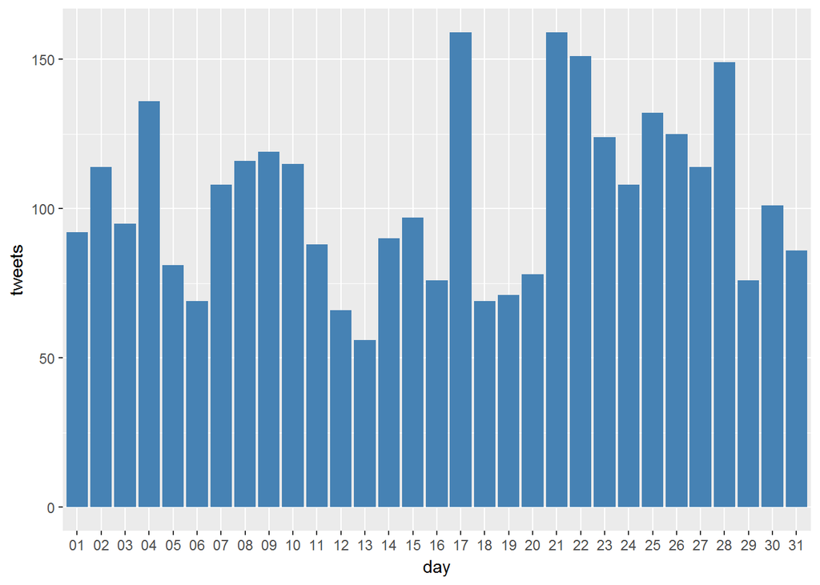

```r
ggplot(t1,aes(day,count)) +geom_bar(stat="identity",fill="steelblue") + ylab("tweets")
```

### 3. What is the difference between data visualization and infographics

A data visualization is a graphical representation of quantifiable data, usually by means of well-known chart, graph or map types. An infographic is a graphical representation that combines one or more data visualizations with other non-data elements - such as graphics or text - to point out relationships, show a process or tell a story that cannot be automatically discerned from the data alone. An infographic requires the application of a creative process with some understanding of the underlying data and its context. Also, information graphics are visual representations of information, data or knowledge often used to support information, strengthen it and present it within a sensitive context. Data visualizations are visual displays of measured quantities by means of the combined use of a coordination system, points, lines, shapes, digits, letters quantified by visual attributes. So, I think the difference is more about the objective. Information graphics are used to tell a story or answer a question. Data visualizations are used to let the user find his own story or answer.

### 4. For the twitter data, identify the number of hashtags used from Jan-2016 to Dec-2016 and plot bar chart for the same

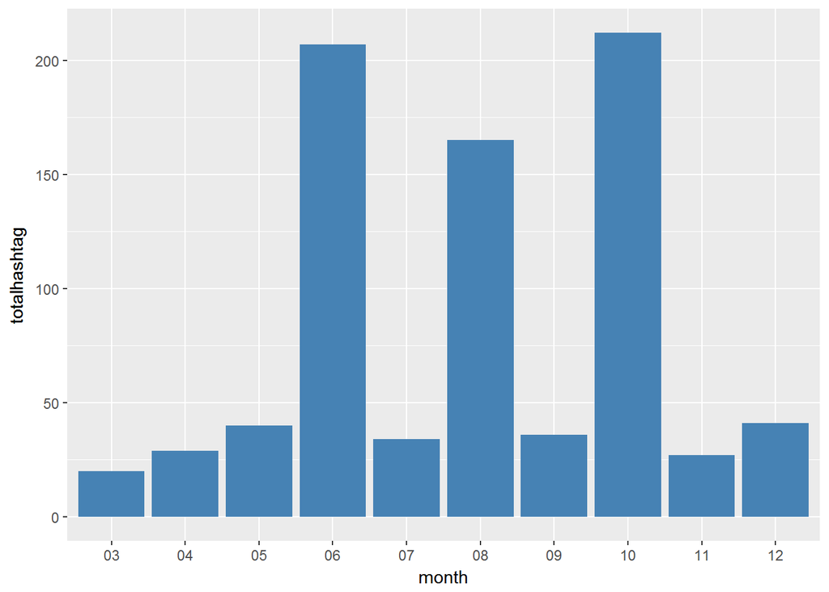

```r
t2 <- tweets %>% group_by(year,month) %>% summarise(totalhashtag= sum(hashtags_count)) %>% filter(year==2016)
ggplot(t2,aes(month,totalhashtag)) + geom_bar(stat="identity",fill="steelblue")
```

### 5. Create a bar chart and identify the second Indian player who has scored more number of runs against Australia

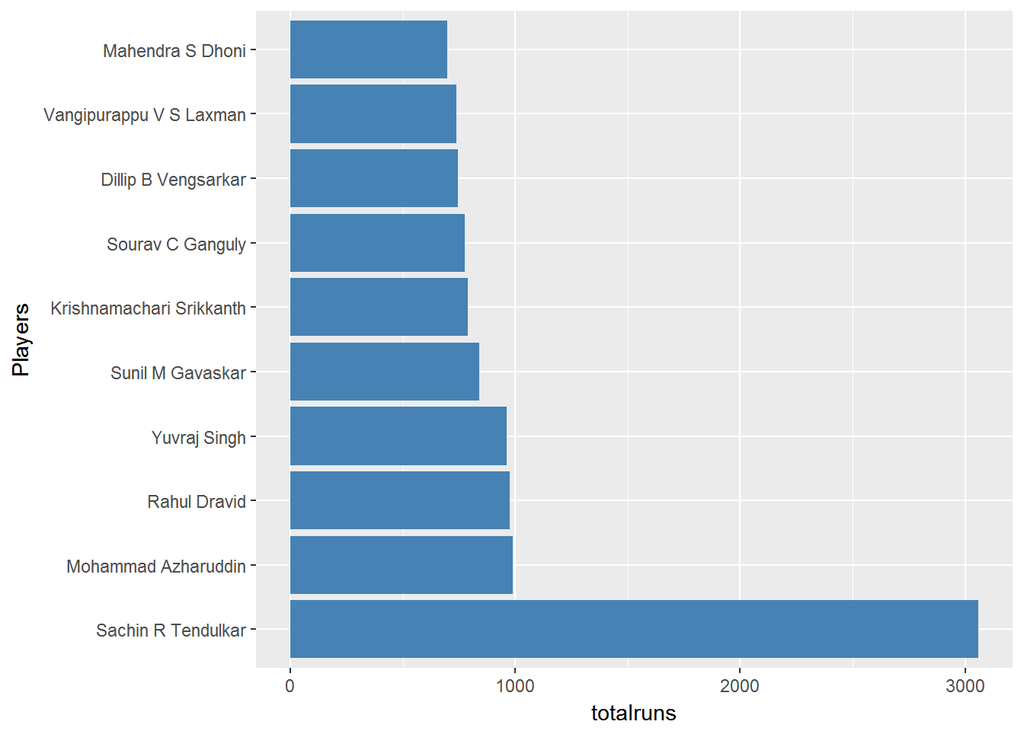

```r
odi_players <- read.csv("C:/Users/Admin/Desktop/data visulisation/odi-batting-analysis.csv")
india <- odi_players %>% filter(Country=="India" & Versus=="Australia") %>% group_by(Player) %>% summarise(totalruns = sum(Runs,na.rm=T)) %>% arrange(-totalruns)
ggplot(head(india,10),aes(factor(Player,levels =unique(Player)),totalruns)) + geom_bar(stat="identity",fill="steelblue") +coord_flip() + xlab("Players")
```

Mohammad Azharuddin has scored 2nd highest runs for india vs australia

### 6. Calculate the total number of runs scored by “Sachin R Tendulkar” against each country

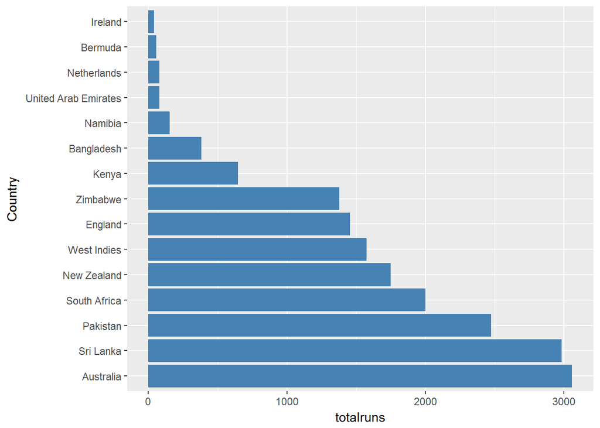

```r
sachin <- odi_players %>% filter(Player=="Sachin R Tendulkar") %>% group_by(Versus) %>% summarise(totalruns = sum(Runs,na.rm=T)) %>% arrange(-totalruns)
ggplot(sachin,aes(factor(Versus,levels=unique(Versus)),totalruns)) + geom_bar(stat="identity",fill="steelblue") +coord_flip() + xlab("Country")
```

### 7. Create a scatterplot for Runs Vs Scorerate for the top 10 Indian players. Add the smooth line to your scatter plot

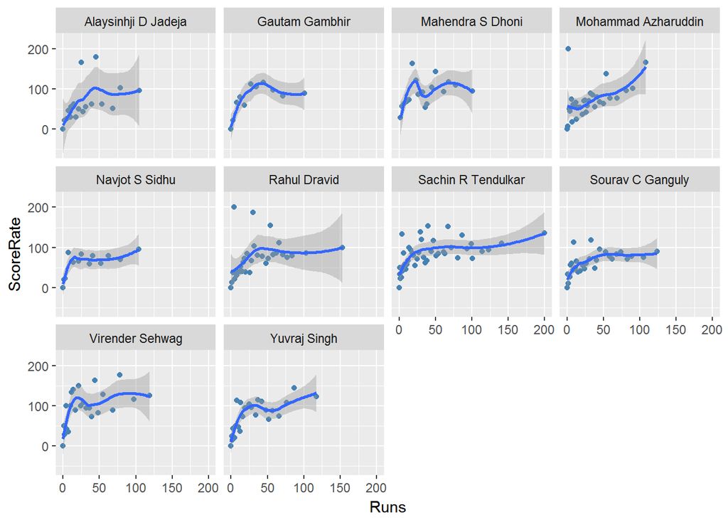

```r
top10 <- odi_players %>% filter(Country=="India") %>% group_by(Player) %>% summarise(totalruns= sum(Runs,na.rm=T)) %>% arrange(-totalruns)
top10 <- head(top10,10)
t3 <- odi_players %>% filter(odi_players$Player == top10$Player)
ggplot(t3,aes(Runs,ScoreRate)) + geom_point(col="steelblue") + geom_smooth() + facet_wrap(~Player)
```

### 8. Identify top 5 players who played cricket for more number of years

```r
moreyears <- odi_players %>% group_by(Player,year) %>% summarise(count= unique(year))
more_years <- moreyears %>% group_by(Player) %>% summarise(count= n()) %>% arrange(-count)
head(more_years,5)
```

```
## # A tibble: 5 × 2
##                   Player count
##                   <fctr> <int>
## 1     Sachin R Tendulkar    23
## 2    Sanath T Jayasuriya    22
## 3          Javed Miandad    20
## 4 Pinnaduwage A de Silva    20
## 5   Muttiah Muralitharan    19
```

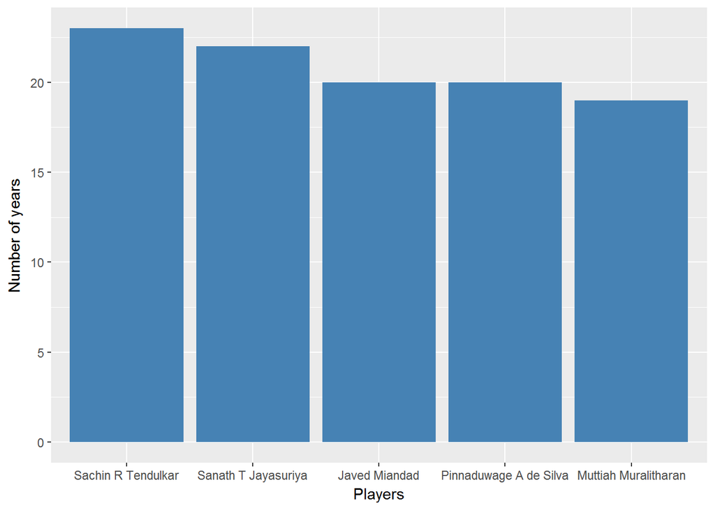

```r
ggplot(head(more_years,5),aes(factor(Player,levels =unique(Player)),count)) + geom_bar(stat="identity",fill="steelblue") + xlab("Players") +ylab("Number of years")
```

### 9. For the twitter data calculate total number of retweets from Jan-2016 to Dec-2016

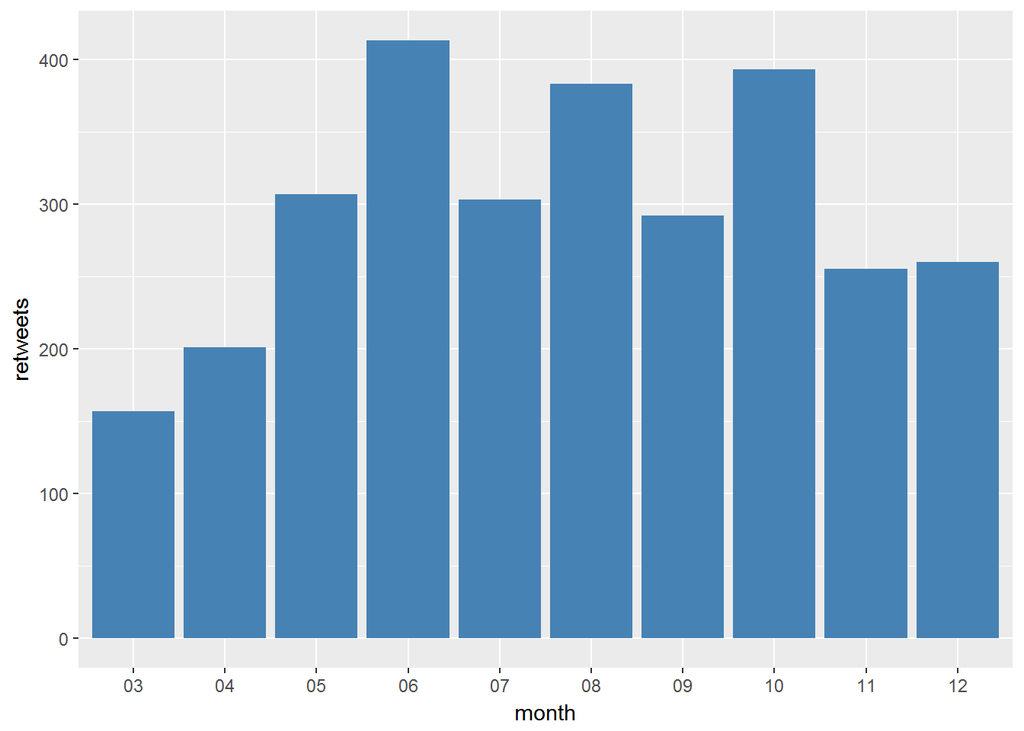

```r
t4 <- tweets %>% filter(year== 2016) %>% group_by(description,month) %>% summarise(retweets = sum(as.numeric(retweeted),na.rm=T))
ggplot(t4,aes(month,retweets)) + geom_bar(stat="identity",fill="steelblue")
```

### 10. Create a bar chart to show top 10 players who has missed more number of centuries

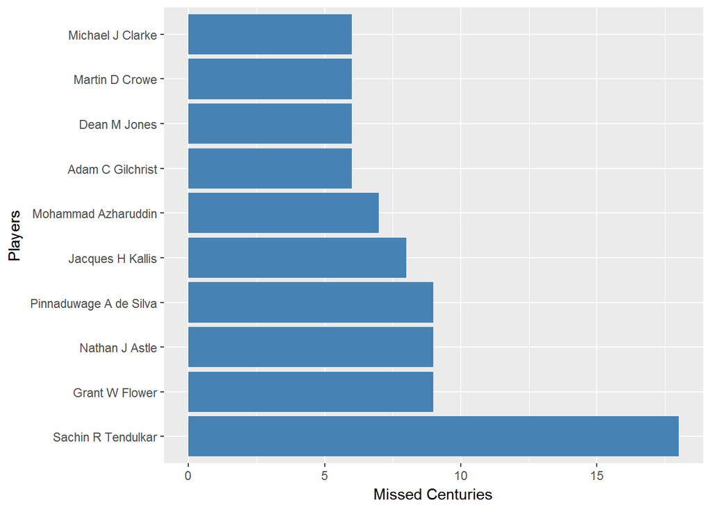

```r
t5 <- odi_players %>% filter(Runs %in% c(90:99)) %>% group_by(Player) %>% summarise(count = n()) %>% arrange(-count)
ggplot(head(t5,10),aes(factor(Player,levels =unique(Player)),count)) + geom_bar(stat= "identity",fill="steelblue") + coord_flip() + xlab("Players") +ylab("Missed Centuries")
```